[figure not shown]

CVT(TR690)-318

Converter Case

CONTINUOUSLY VARIABLE TRANSMISSION

50.Converter Case

A: REMOVAL

1) Remove the transmission assembly from the vehicle. <Ref. to CVT(TR690)-56, REMOVAL, Automatic

Transmission Assembly.>

2) Remove the air breather hose. <Ref. to CVT(TR690)-136, REMOVAL, Air Breather Hose.>

3) Remove the oil pan and control valve body. <Ref. to CVT(TR690)-112, REMOVAL, Control Valve Body.>

4) Remove the transmission harness. <Ref. to CVT(TR690)-123, REMOVAL, Transmission Harness.>

5) Remove the secondary pressure sensor. <Ref. to CVT(TR690)-110, REMOVAL, Secondary Pressure

Sensor.>

6) Remove the primary speed sensor. <Ref. to CVT(TR690)-102, REMOVAL, Primary Speed Sensor.>

7) Remove the extension case. <Ref. to CVT(TR690)-142, REMOVAL, Extension Case.>

8) Remove the rear drive shaft. <Ref. to CVT(TR690)-146, REMOVAL, Rear Drive Shaft.>

9) Remove the transfer clutch assembly. <Ref. to CVT(TR690)-151, REMOVAL, Transfer Clutch.>

10) Remove the center differential carrier. <Ref. to CVT(TR690)-154, REMOVAL, Center Differential Carri-

er.>

11) Remove the transfer reduction driven gear assembly. <Ref. to CVT(TR690)-158, REMOVAL, Transfer

Reduction Driven Gear.>

12) Remove the intermediate case. <Ref. to CVT(TR690)-165, REMOVAL, Intermediate Case.>

13) Remove the forward clutch assembly. <Ref. to CVT(TR690)-181, REMOVAL, Forward Clutch Assem-

bly.>

14) Remove the transmission case. <Ref. to CVT(TR690)-212, REMOVAL, Transmission Case.>

15) Remove the primary pulley, secondary pulley and variator chain. <Ref. to CVT(TR690)-228, REMOVAL,

Primary Pulley and Secondary Pulley.>

16) Remove the drive pinion shaft assembly. <Ref. to CVT(TR690)-244, REMOVAL, Drive Pinion Shaft As-

sembly.>

17) Remove the front differential assembly. <Ref. to CVT(TR690)-265, REMOVAL, Front Differential Assem-

bly.>

18) Remove the converter case cover. <Ref. to CVT(TR690)-292, REMOVAL, Converter Case Cover.>

19) Remove the front reduction drive gear and front reduction driven gear. <Ref. to CVT(TR690)-302, RE-

MOVAL, Front Reduction Drive Gear.>

B: INSTALLATION

1) Install the front reduction drive gear and front reduction driven gear. <Ref. to CVT(TR690)-303, INSTAL-

LATION, Front Reduction Drive Gear.>

2) Install the converter case cover. <Ref. to CVT(TR690)-295, INSTALLATION, Converter Case Cover.>

3) Install the front differential assembly. <Ref. to CVT(TR690)-266, INSTALLATION, Front Differential As-

sembly.>

4) Install the drive pinion shaft assembly. <Ref. to CVT(TR690)-246, INSTALLATION, Drive Pinion Shaft As-

sembly.>

5) Install the primary pulley, secondary pulley and steel chain. <Ref. to CVT(TR690)-232, INSTALLATION,

Primary Pulley and Secondary Pulley.>

7) Install the forward clutch assembly. <Ref. to CVT(TR690)-182, INSTALLATION, Forward Clutch Assembly.>

8) Install the intermediate case. <Ref. to CVT(TR690)-166, INSTALLATION, Intermediate Case.>

9) Install the transfer reduction driven gear. <Ref. to CVT(TR690)-158, INSTALLATION, Transfer Reduction

Driven Gear.>

10) Install the center differential carrier. <Ref. to CVT(TR690)-155, INSTALLATION, Center Differential Carrier.>

11) Install the transfer clutch assembly. <Ref. to CVT(TR690)-151, INSTALLATION, Transfer Clutch.>

12) Install the rear drive shaft. <Ref. to CVT(TR690)-146, INSTALLATION, Rear Drive Shaft.>

13) Install the extension case. <Ref. to CVT(TR690)-143, INSTALLATION, Extension Case.>

14) Install the primary speed sensor. <Ref. to CVT(TR690)-103, INSTALLATION, Primary Speed Sensor.>

15) Install the secondary pressure sensor. <Ref. to CVT(TR690)-110, INSTALLATION, Secondary Pressure

Sensor.>

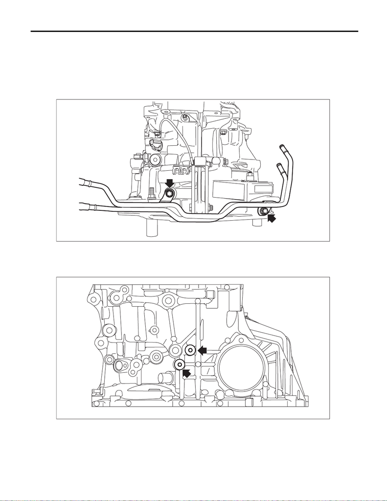

CVT(TR690)-319

Converter Case

CONTINUOUSLY VARIABLE TRANSMISSION

16) Install the transmission harness. <Ref. to CVT(TR690)-125, INSTALLATION, Transmission Harness.>

17) Install the control valve body and oil pan. <Ref. to CVT(TR690)-116, INSTALLATION, Control Valve Body.>

18) Install the air breather hose. <Ref. to CVT(TR690)-136, INSTALLATION, Air Breather Hose.>

19) Install the transmission assembly to the vehicle. <Ref. to CVT(TR690)-69, INSTALLATION, Automatic

Transmission Assembly.>

C: DISASSEMBLY

1) Remove the CVTF cooler pipe COMPL.

2) Remove the pitching stopper bracket and transmission radio ground cord, if mounted.

3) Remove the oil drain plug and overflow drain plug. <Ref. to CVT(TR690)-42, REPLACEMENT, Differential

Gear Oil.>

4) Remove all plugs.

AT-07841

AT-07554

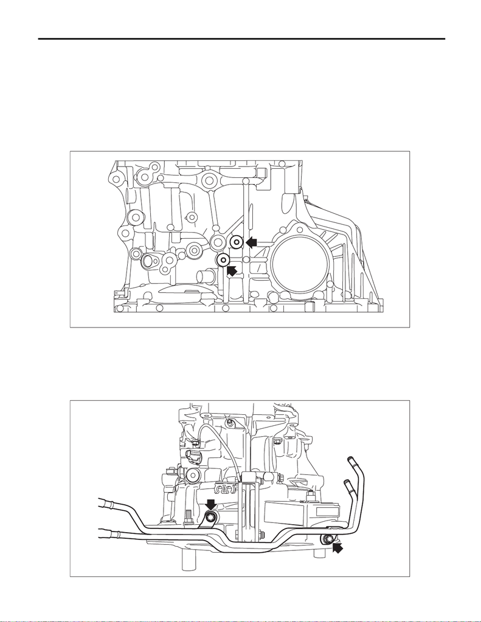

CVT(TR690)-320

Converter Case

CONTINUOUSLY VARIABLE TRANSMISSION

D: ASSEMBLY

1) Install the oil drain plug and overflow drain plug.

NOTE:

Overflow plug of differential gear oil is temporarily attached.

2) Install all plugs.

NOTE:

Use new O-rings.

Tightening torque:

25 N·m (2.5 kgf-m, 18.4 ft-lb)

3) Install the pitching stopper bracket and transmission radio ground cord.

Tightening torque:

41 N·m (4.2 kgf-m, 30.2 ft-lb)

4) Install the CVTF cooler pipe COMPL.

Tightening torque:

16 N·m (1.6 kgf-m, 11.8 ft-lb)

AT-07554

AT-07841

[figure not shown]

CVT(TR690)-321

Converter Case

CONTINUOUSLY VARIABLE TRANSMISSION

E: INSPECTION

• Check for leakage of CVTF from the connection between converter case and transmission case.

• Check there is no damage or cracks on the converter case.

F: ADJUSTMENT

When replacing the converter case cover, select the following shims.

• Select the shim for front reduction drive gear. <Ref. to CVT(TR690)-308, ADJUSTMENT, Front Reduction

Drive Gear.>

• Select the shim for front reduction driven gear. <Ref. to CVT(TR690)-316, ADJUSTMENT, Front Reduc-

tion Driven Gear.>

• Select shims for primary pulley. <Ref. to CVT(TR690)-238, ADJUSTMENT, Primary Pulley and Secondary

Pulley.>